# Import Vector Data

This Notebook will demonstrate how to import various types of vector GIS data into R.

## View Layers for Yosemite National Park

First let’s look at layers in the data folder, by passing the directory to `st_layers()` from the `sf` package. This will show us the Shapefiles but not layers that are in ‘containers’, like file geodatabases, geojson files, etc.

```r
library(sf)

## View spatial layers in the data folder.
st_layers("./data")
```

```
Driver: ESRI Shapefile
Available layers:
```

| layer_name | geometry_type | features | fields | crs_name |
| --- | --- | --- | --- | --- |
| sf_schools | Point | 445 | 15 | WGS 84 |
| veg37 | Polygon | 6512 | 26 | NAD83 / UTM zone 11N |
| yose_boundary | Polygon | 1 | 11 | North_American_Datum_1983 |
| yose_poi | Point | 2720 | 30 | NAD83 / UTM zone 11N |
| veg37_alliances | NA | 39 | 3 | NA |

## Import a Shapefile

Import the ‘yose_boundary’ layer (a Shapefile)

```r
yose_bnd_ll <- st_read(dsn="./data", layer="yose_boundary")
# This also works:
# yose_bnd_ll <- st_read(dsn="./data/yose_boundary.shp")
```

Note 1: we don’t need to add the .shp extension

Note 2: this code is using convention to name variables *yose_bnd_ll*.

`yose` - all Yosemite layers start with this  
`bnd` - tell me this the park boundary  
`ll` - lat-long coordinates

## CHALLENGE: View the Object class

Write an expression that returns the class (type) of *yose_bnd_ll*. [Answer](http://bit.ly/39cVjNZ)

```r
## View the class of the object we just created
class(yose_bnd_ll)
```

```
[1] "sf"         "data.frame"
```

We see that `yose_bnd_ll` is both a sf object (simple feature data frame) as well as a data.frame. This means we should be able to use the functions designed for either of those objects.

View the properties of *yose_bnd_ll* by simply running it by itself:

```r
yose_bnd_ll
```

```
Simple feature collection with 1 feature and 11 fields
Geometry type: POLYGON
Dimension:     XY
Bounding box:  xmin: -119.8864 ymin: 37.4947 xmax: -119.1964 ymax: 38.18515
Geodetic CRS:  North_American_Datum_1983
  UNIT_CODE                                                                           GIS_NOTES              UNIT_NAME
1      YOSE Lands - http://landsnet.nps.gov/tractsnet/documents/YOSE/METADATA/yose_metadata.xml Yosemite National Park
   DATE_EDIT STATE REGION GNIS_ID     UNIT_TYPE CREATED_BY                                               METADATA PARKNAME
1 2016-01-27    CA     PW  255923 National Park      Lands http://nrdata.nps.gov/programs/Lands/YOSE_METADATA.xml Yosemite
                        geometry
1 POLYGON ((-119.8456 37.8327...
```

## CHALLENGE: Which CRS?

What coordinate reference system is *yose_bnd_ll* in? [Answer](http://bit.ly/38UY2ve)

**ANS**. Unprojected geographic coordinates (lon-lat) in the NAD83 datum.

## View the Attribute Table

The `names()` function returns the column labels of a data frame (in this case the attribute table).

```r
## View column names in the attribute table
names(yose_bnd_ll)
```

```
 [1] "UNIT_CODE"  "GIS_NOTES"  "UNIT_NAME"  "DATE_EDIT"  "STATE"      "REGION"     "GNIS_ID"    "UNIT_TYPE"  "CREATED_BY"
[10] "METADATA"   "PARKNAME"   "geometry"
```

Take note of the last column - `geometry`. That’s where the geometry is saved (we’ll come back to that later).

View the first few rows of the attribute table with `head()`:

```r
head(yose_bnd_ll)
```

```
Simple feature collection with 1 feature and 11 fields
Geometry type: POLYGON
Dimension:     XY
Bounding box:  xmin: -119.8864 ymin: 37.4947 xmax: -119.1964 ymax: 38.18515
Geodetic CRS:  North_American_Datum_1983
  UNIT_CODE                                                                           GIS_NOTES              UNIT_NAME
1      YOSE Lands - http://landsnet.nps.gov/tractsnet/documents/YOSE/METADATA/yose_metadata.xml Yosemite National Park
   DATE_EDIT STATE REGION GNIS_ID     UNIT_TYPE CREATED_BY                                               METADATA PARKNAME
1 2016-01-27    CA     PW  255923 National Park      Lands http://nrdata.nps.gov/programs/Lands/YOSE_METADATA.xml Yosemite
                        geometry
1 POLYGON ((-119.8456 37.8327...
```

## Plot the Yosemite Boundary

To plot just the geometry of a sf object (i.e., no symbology from the attribute table), we can use the `st_geometry()` function.

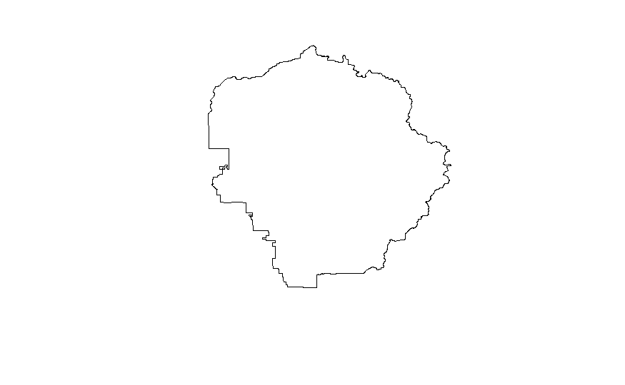

```r
## Plot the geometry (outline) of the Yosemite boundary
plot(yose_bnd_ll %>% st_geometry(), asp=1)
```

## CHALLENGE: Add Axes

Add `axes=TRUE` to your plot() statement. [Answer](http://bit.ly/3lwqo48)

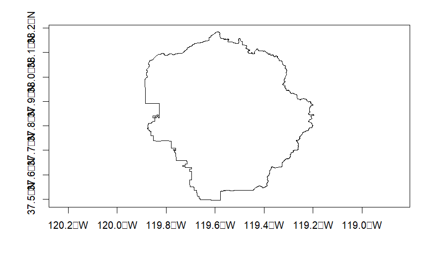

```r
## Plot the geometry (outline) of the Yosemite boundary
plot(yose_bnd_ll %>% st_geometry(), asp=1, axes=TRUE)
```

## CHALLENGE: Import POI Shapefile

Import the Yosemite Points-of-Interest (POI) Shapefile and plot them. [Answer](http://bit.ly/3cSAEQi)

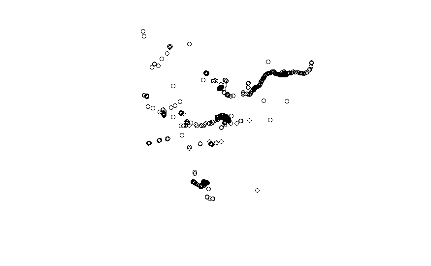

```r
## Import the yose_poi.shp
yose_poi_ll <- st_read(dsn="./data", layer="yose_poi")
plot(yose_poi_ll %>% st_geometry())
```

## Import a KML

kml & kmz files can have more than one layer. Hence the source is the kml file, and you must specify the layer by name.

Import a kml containing the National Register of Historic Places in Yosemite in Yosemite. First find the KML file:

```r
## Import KML file
kml_fn <- "./data/yose_historic_pts.kml"
file.exists(kml_fn)
```

```
[1] TRUE
```

View the layers within this KML:

```r
## View the layers in this kml
st_layers(kml_fn)
```

```
Driver: KML
Available layers:
```

| layer_name | geometry_type | features | fields | crs_name |
| --- | --- | --- | --- | --- |
| yose_historic_places | Point | 35 | 2 | WGS 84 |

Import:

```r
## Import the 'yosem_historic_places' layer
yose_hp_ll <- st_read(kml_fn, layer="yose_historic_places")
```

View its properties:

```r
## View properties
yose_hp_ll
```

```
Simple feature collection with 35 features and 2 fields
Geometry type: POINT
Dimension:     XY
Bounding box:  xmin: -119.8447 ymin: 37.51356 xmax: -119.2165 ymax: 38.08368
Geodetic CRS:  WGS 84
First 10 features:
                                 Name Description                   geometry
1  Hetch Hetchy Railroad Engine No. 6              POINT (-119.786 37.67437)
2             Hodgdon Homestead Cabin              POINT (-119.656 37.53924)
3                       Rangers' Club             POINT (-119.5883 37.74735)
4                    Buck Creek Cabin             POINT (-119.4897 37.56131)
5               Wawona Covered Bridge              POINT (-119.656 37.53859)
6             Crane Flat Fire Lookout             POINT (-119.8207 37.75978)
7      Glacier Point Trailside Museum             POINT (-119.5731 37.72916)
8                      McCauley Cabin             POINT (-119.3676 37.87812)
9                  Bagby Stationhouse             POINT (-119.7862 37.67439)
10                  Great Sierra Mine              POINT (-119.2688 37.9276)
```

## Plot the Historic Places on top of the Park Boundary

Remember to overlay more than one layer on a plot:

- both layers must have the same CRS
- include add=TRUE to the plot statements

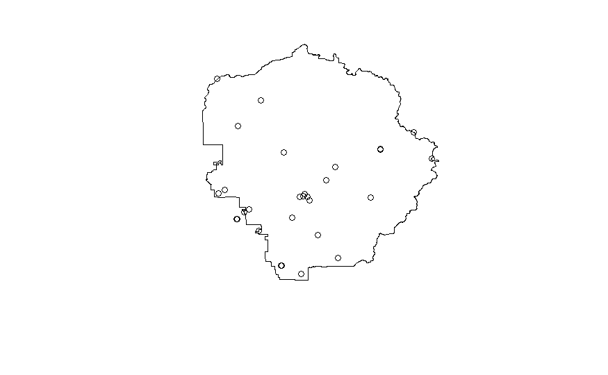

```r
## Plot the boundary, then the historic places
{plot(yose_bnd_ll %>% st_geometry(), asp=1)
plot(yose_hp_ll %>% st_geometry(), add=TRUE)}
```

## Import a GeoJSON file

Import the California county boundaries, which is saved as a GeoJSON file.

```r
## Import a Geojson file
counties_fn <- "./data/ca_counties.geojson"
file.exists(counties_fn)
```

```
[1] TRUE
```

View the layers in this GeoJSON file:

```r
## View the layers
st_layers(counties_fn)
```

```
Driver: GeoJSON
Available layers:
```

| layer_name | geometry_type | features | fields | crs_name |
| --- | --- | --- | --- | --- |
| ca_counties | 3D Multi Polygon | 58 | 13 | WGS 84 |

Import the ‘ca_counties’ layer:

```r
## Import the 'ca_counties' layer
ca_counties_ll <- st_read(counties_fn)
```

## CHALLENGE: Plot Counties

Plot the county boundaries. [Answer](http://bit.ly/38YeWJs)

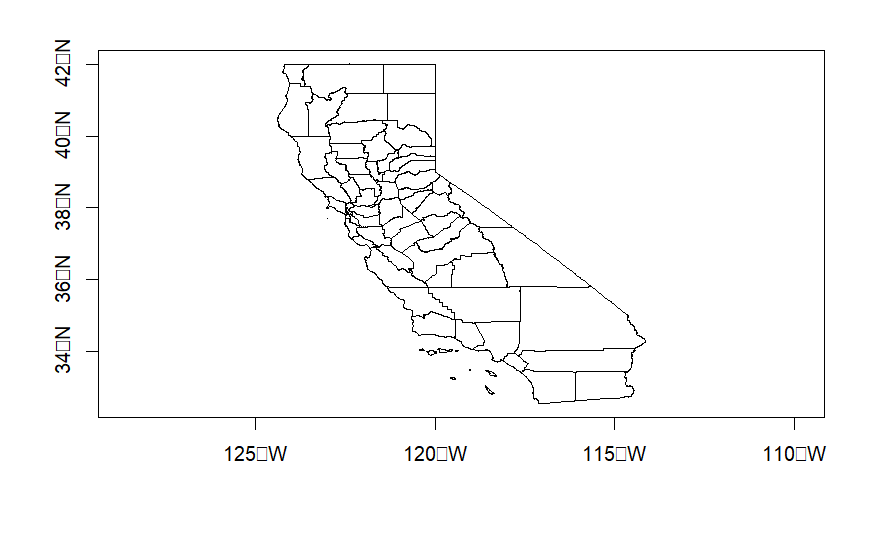

```r
plot(ca_counties_ll %>% st_geometry(), asp=1, axes=TRUE)
```

## Import from a Geodatabase

You can import (but not write to) an ESRI file geodatabase using the sf package. In this case, the source is the folder containing the geodatabase.

Import the Yosemite’s trails from a geodatabase. First find the gdb file:

```r
## Define the path to the file geodatabase (a folder)
gdb_fn <- "./data/yose_trails.gdb"
file.exists(gdb_fn)
```

```
[1] TRUE
```

View the layers in this source:

```r
st_layers(gdb_fn)
```

```
Driver: OpenFileGDB
Available layers:
```

| layer_name | geometry_type | features | fields | crs_name |
| --- | --- | --- | --- | --- |
| Trailheads | Point | 73 | 5 | NAD83 / UTM zone 11N |
| Trails | Multi Line String | 1074 | 13 | NAD83 / UTM zone 11N |
| Wilderness_stock_routes | Multi Line String | 11 | 6 | NAD83 / UTM zone 11N |
| Winter_trails | Multi Line String | 24 | 5 | NAD83 / UTM zone 11N |
| T_1_DirtyAreas | Multi Polygon | 1 | 3 | NAD83 / UTM zone 11N |
| T_1_PointErrors | Point | 260 | 7 | NAD83 / UTM zone 11N |
| T_1_LineErrors | Multi Line String | 0 | 8 | NAD83 / UTM zone 11N |
| T_1_PolyErrors | Multi Polygon | 0 | 9 | NAD83 / UTM zone 11N |

Import the ‘Trails’ layer

```r
## Import the 'Trails' layer  (case sensitive!)
yose_trails <- st_read(gdb_fn, layer="Trails")
```

Plot Yosemite’s Trails:

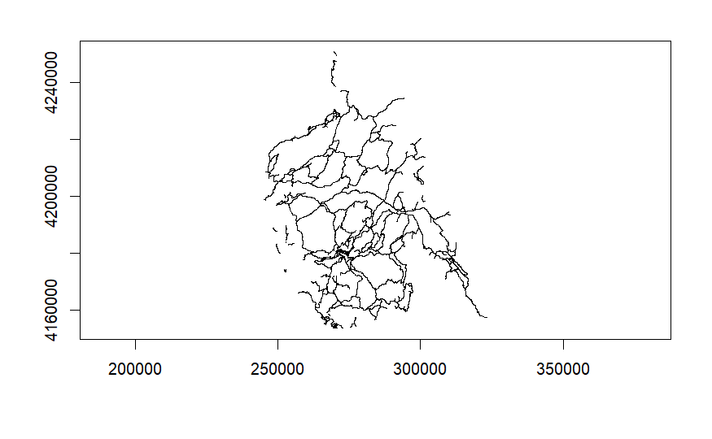

```r
## Plot the trails layer
plot(st_geometry(yose_trails), axes=TRUE)
```

## CHALLENGE: Diagnose a Bad Plot

The following code does **not** work to make a plot of the park boundary and the trails. Can you tell why? [Answer](http://bit.ly/3eSGOlZ)

**ANS**. Because the CRS are different!

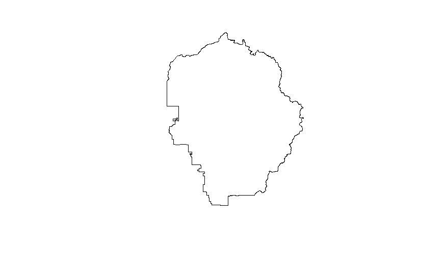

```r
{plot(yose_bnd_ll %>% st_geometry())
plot(yose_trails %>% st_geometry(), add=TRUE)}
```

## Import from a GeoPackage

Let’s import Yosemite’s watersheds from a geopackage file.

```r
## Import watersheds from a geopackage
gpkg_watershd_fn <- "./data/yose_watersheds.gpkg"
file.exists(gpkg_watershd_fn)
```

```
[1] TRUE
```

```r
st_layers(gpkg_watershd_fn)
```

```
Driver: GPKG
Available layers:
```

| layer_name | geometry_type | features | fields | crs_name |
| --- | --- | --- | --- | --- |
| calw221 | Polygon | 127 | 12 | NAD83 / California Albers |

```r
yose_watersheds <- st_read(gpkg_watershd_fn, layer="calw221")
```

Plot the watersheds:

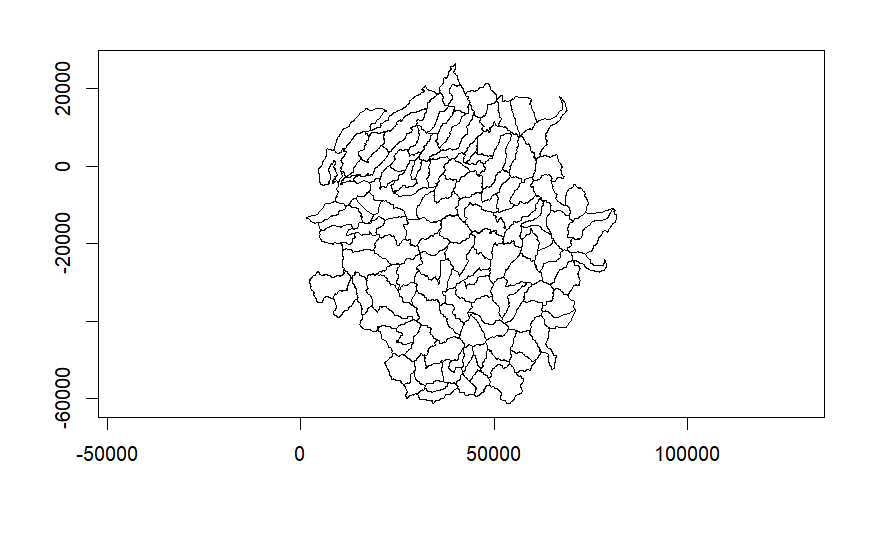

```r
plot(st_geometry(yose_watersheds), axes=TRUE)
```

## CHALLENGE: What CRS?

What CRS are the Yosemite watersheds in? [Answer](http://bit.ly/38XePO7)

**ANS**. California Equal Albers (a common projection for statewide data in California)

```r
st_crs(yose_watersheds)
```

```
Coordinate Reference System:
  User input: NAD83 / California Albers
  wkt:
PROJCRS["NAD83 / California Albers",
    BASEGEOGCRS["NAD83",
        DATUM["North American Datum 1983",
            ELLIPSOID["GRS 1980",6378137,298.257222101,
                LENGTHUNIT["metre",1]]],
        PRIMEM["Greenwich",0,
            ANGLEUNIT["degree",0.0174532925199433]],
        ID["EPSG",4269]],
    CONVERSION["California Albers",
        METHOD["Albers Equal Area",
            ID["EPSG",9822]],
        PARAMETER["Latitude of false origin",0,
            ANGLEUNIT["degree",0.0174532925199433],
            ID["EPSG",8821]],
        PARAMETER["Longitude of false origin",-120,
            ANGLEUNIT["degree",0.0174532925199433],
            ID["EPSG",8822]],
        PARAMETER["Latitude of 1st standard parallel",34,
            ANGLEUNIT["degree",0.0174532925199433],
            ID["EPSG",8823]],
        PARAMETER["Latitude of 2nd standard parallel",40.5,
            ANGLEUNIT["degree",0.0174532925199433],
            ID["EPSG",8824]],
        PARAMETER["Easting at false origin",0,
            LENGTHUNIT["metre",1],
            ID["EPSG",8826]],
        PARAMETER["Northing at false origin",-4000000,
            LENGTHUNIT["metre",1],
            ID["EPSG",8827]]],
    CS[Cartesian,2],
        AXIS["easting (X)",east,
            ORDER[1],
            LENGTHUNIT["metre",1]],
        AXIS["northing (Y)",north,
            ORDER[2],
            LENGTHUNIT["metre",1]],
    USAGE[
        SCOPE["State-wide spatial data management."],
        AREA["United States (USA) - California."],
        BBOX[32.53,-124.45,42.01,-114.12]],
    ID["EPSG",3310]]
```

## Import a CSV file

Import a CSV file containing missing persons records. Step 1 is to import it as a data frame:

```r
## Import missing people csv file
missing_df <- read.csv("./data/yosemite_missing_people.csv", stringsAsFactors = FALSE)
tibble::glimpse(missing_df)
```

```
Rows: 213
Columns: 49
$ X          <dbl> -119.6632, -119.8099, -119.5958, -119.5599, -119.5937, -119.6064, -119.4291, -119.5864, -119.5271, -119…
$ Y          <dbl> 37.66355, 37.76910, 37.74595, 37.75631, 37.74561, 37.74521, 37.86868, 37.71233, 37.74873, 37.73601, 37.…
$ OBJECTID_1 <int> 1, 2, 3, 4, 5, 6, 7, 8, 9, 10, 11, 12, 13, 14, 15, 16, 17, 18, 19, 20, 21, 22, 23, 24, 25, 26, 27, 28, …
$ OBJECTID   <int> 1, 2, 3, 4, 5, 6, 7, 8, 9, 10, 11, 12, 13, 14, 15, 16, 17, 18, 19, 20, 21, 22, 23, 24, 25, 26, 27, 28, …
$ Georef_Unc <dbl> 336.3710, 526.3630, 56.3650, 126.3640, 41.3650, 846.5152, 41.3560, 51.3670, 41.3650, 431.3660, 41.3560,…
$ Distance   <dbl> 1340.26046, 1293.06310, 0.00000, 1760.04205, 357.14291, 1823.43718, 651.53949, 2971.29565, 3025.12285, …
$ Type       <chr> "IPP", "IPP", "IPP", "IPP", "IPP", "IPP", "IPP", "IPP", "IPP", "IPP", "IPP", "IPP", "IPP", "IPP", "IPP"…
$ Lat        <dbl> 37.66355, 37.76910, 37.74595, 37.75631, 37.74561, 37.74521, 37.86868, 37.71233, 37.74873, 37.73601, 37.…
$ Long       <dbl> -119.6632, -119.8099, -119.5958, -119.5599, -119.5937, -119.6064, -119.4291, -119.5864, -119.5271, -119…
$ Extent     <dbl> 310, 500, 30, 100, 15, 15, 15, 25, 15, 405, 15, 30, 150, 15, 47, 70, 15, 15, 15, 15, 468, 200, 40, 15, …
$ CaseNumber <int> 20090248, 20090652, 20090940, 20091134, 20091252, 20091345, 20091382, 20091583, 20091755, 20091760, 200…
$ SARNumber  <int> 2009004, 2009014, 2009024, 2009029, 2009036, 2009042, 2009043, 2009052, 2009059, 2009060, 2009069, 2009…
$ IncidYear  <int> 2009, 2009, 2009, 2009, 2009, 2009, 2009, 2009, 2009, 2009, 2009, 2009, 2009, 2009, 2009, 2009, 2009, 2…
```

[output cut: 36 more lines]

Step 2 is to convert it to a sf data frame. We can surmise from the column names that the coordinates are geographic. We don’t know precisely which datum, but passing crs=4326 (WGS84) will be close enough.

```r
## Convert to sf and plot
yose_missing_ll <- st_as_sf(missing_df, coords=c("Long", "Lat"), crs=4326)
```

Plot to make sure:

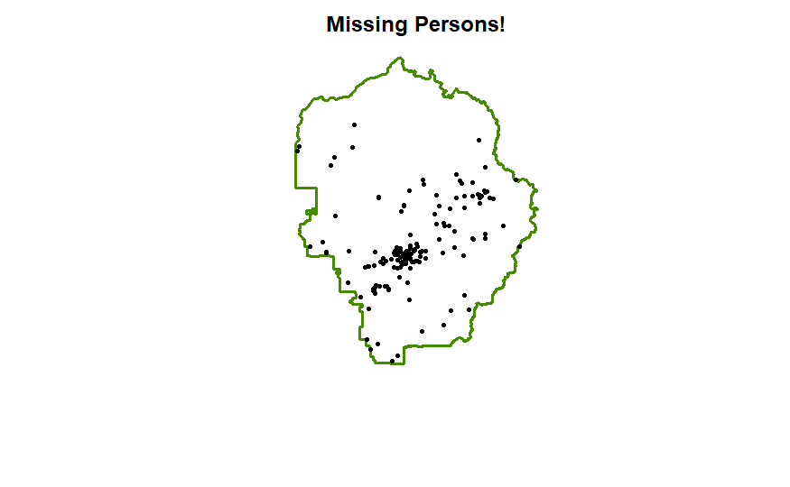

```r
{plot(yose_bnd_ll %>% st_geometry(), col=NA, border="chartreuse4", lwd=3, main = "Missing Persons!")
plot(yose_missing_ll %>% st_geometry(), pch=16, cex=0.5, add=TRUE)}
```

## CHALLENGE: Import another Layer

Look at the other GIS files in the data folder. Select one, import it, and plot it.

```r
## Your answer here
```